# Visualizing Earth-Observing Satellites

Gavin McNicol

2021-08-02

### Read in data

This exercise uses data from [The Union of Concerned Scientists (UCS) Satellite Database](https://www.ucsusa.org/satellite_database). The UCS Satellite Database is a listing of active satellites currently in orbit around the Earth.

```r
satellites <- read.csv("UCS-Satellite-Database-1-1-2021.csv")
```

### Glimpse the satellites data frame.

```r
glimpse(satellites)
```

```
## Rows: 3,372
## Columns: 28
## $ name                  <chr> "1HOPSAT-TD (1st-generation High Optical Perform…
## $ official_name         <chr> "1HOPSAT", "3Cat-1", "Aalto-1", "AAUSat-4", "ABS…
## $ country_origin        <chr> "NR (12/20)", "NR", "Finland", "Denmark", "NR", …
## $ country_operator      <chr> "USA", "Spain", "Finland", "Denmark", "Multinati…
## $ operator              <chr> "Hera Systems", "Universitat Politècnica de Cata…
## $ user                  <chr> "Commercial", "Civil", "Civil", "Civil", "Commer…
## $ purpose               <chr> "Earth Observation", "Technology Development", "…
## $ purpose_detailed      <chr> "Technology Development", "", "", "Automatic Ide…
## $ orbit_class           <chr> "LEO", "LEO", "LEO", "LEO", "GEO", "GEO", "GEO",…
## $ orbit_type            <chr> "Non-Polar Inclined", "", "", "Sun-Synchronous",…
## $ longitude_geo_degrees <dbl> 0.00, 0.00, 0.00, 0.00, 75.00, -75.00, -3.00, 75…
## $ perigee_km            <int> 566, 476, 497, 442, NA, NA, NA, NA, NA, NA, NA, …
## $ apogee_km             <int> 576, 500, 517, 687, NA, NA, NA, NA, NA, NA, NA, …
## $ eccentricity          <dbl> 0.000720, 0.001750, 0.001450, 0.017700, 0.000178…
## $ inclination_degrees   <dbl> 36.90, 97.40, 97.45, 98.20, 0.08, 0.00, 0.10, 0.…
## $ period_minutes        <dbl> 96.08, 95.00, 94.70, 95.90, 1436.03, 1436.10, 14…
## $ launch_mass_kg        <int> 22, 4, 5, 1, NA, NA, NA, NA, NA, NA, NA, NA, NA,…
## $ dry_mass_kg           <int> NA, NA, NA, NA, NA, NA, NA, NA, NA, NA, NA, NA, …
## $ power_watts           <dbl> NA, NA, 4.5, NA, NA, NA, NA, NA, NA, NA, NA, NA,…
## $ launch_date           <chr> "12/11/19", "11/29/18", "6/23/17", "4/25/16", "2…
## $ expected_lifetime_yrs <dbl> 0.5, NA, 2.0, NA, 15.0, 15.0, 15.0, 12.0, 15.0, …
## $ contractor            <chr> "Hera Systems", "Universitat Politècnica de Cata…
## $ contractor_country    <chr> "USA", "Spain", "Finland", "Denmark", "USA", "US…
## $ launch_site           <chr> "Satish Dhawan Space Centre", "Satish Dhawan Spa…
## $ launch_vehicle        <chr> "PSLV", "PSLV", "PSLV", "Soyuz 2.1a", "Ariane 5 …
## $ cospar_number         <chr> "2019-089H", "2018-096K", "2017-036L", "2016-025…
## $ norad_number          <int> 44859, 43728, 42775, 41460, 39508, 41588, 40424,…
## $ comments              <chr> "Pathfinder for planned earth observation conste…
```

### Exercise 1.

Modify the following plot to change the color of all points to `"pink"`.

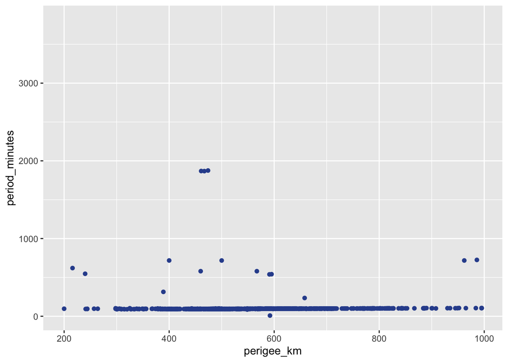

```r
ggplot(satellites,
       aes(x = perigee_km, y = period_minutes, color = country_origin)) +
  geom_point(color = "#30509C")
```